# Metropolis Hasting

## Contoh Metropolis Hasting (3)

Diketahui pengamatan $x_{1}, x_{2}, \dots, x_{n}$, mengikuti model eksponensial $p(x|a,b)= ab \ esp(-abx); x>0;a,b>0$ dengan prior:

$$\begin{align*}
p(a,b)= exp(-a -b); a,b>0
\end{align*}$$

Estimasi parameter $a$ dan $b$ Catatan: data dibangkitkan dengan perintah

```r
data <- rexp(100,4*5)
```

Likelihood dari model eksponensial tersebut adalah

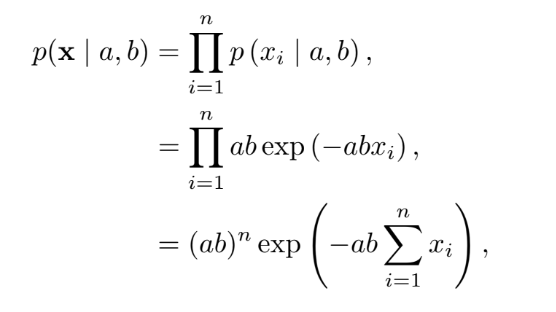

dan priornya adalah

$$\begin{align*}
p(a,b) & = exp(-a -b)\\
& = exp(-a)exp(-b)
\end{align*}$$

Posteriornya:

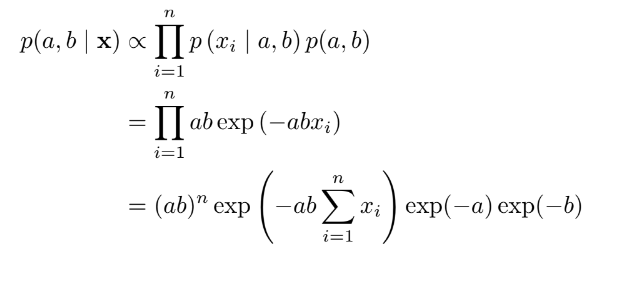

Jawab: Misalkan $\theta=(a,b)$, kandidat sampel diperoleh dari distribusi proposal yang digunakan adalah Logn Normal, karena $a,b>0$, bisa juga menggunakan distribusi normal (di contoh selanjutnya).

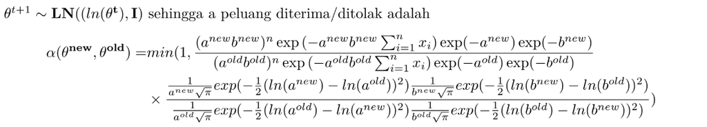

```r
MHfunc <- function(a, b, n, data){ #n=banyak iterasi

  theta <- matrix(rep(0, 2*n), n, 2)

  # inisial
  theta[1, 1:2] <- c(a, b)

  # hiperparameter
  for(i in 2:n){
    a.new<-(rlnorm(1,log(theta[i-1,1]),1))
    b.new<-(rlnorm(1,log(theta[i-1,2]),1))
    log.postnew<-sum(dexp(data,a.new*b.new,log=TRUE))+dexp(a.new,log=TRUE) +
      dexp(b.new,log=TRUE)+dlnorm(a.new,log(theta[(i-1),1]),1,log=TRUE) +
      dlnorm(b.new,log(theta[(i-1),2]),1,log=TRUE)
    log.postold<-sum(dexp(data,theta[i-1,(1)]*theta[i-1,(2)],log=TRUE)) +
      dexp(theta[i-1,(1)],log=TRUE) +
      dexp(theta[i-1,2],log=TRUE)+dlnorm(theta[(i-1),1],log(a.new),1,log=TRUE) +
      dlnorm(theta[(i-1),2],log(b.new),log=TRUE)
    logprob <- log.postnew - log.postold
    aprob <- min(1, exp(logprob))
    u <- runif(1)
    if (u < aprob){
      theta[i,(1:2)] <- c(a.new, b.new)
    }else{
      theta[i,(1:2)] <- theta[i-1, (1:2)]
    }
  }

  theta
}
```

### Menjalankan fungsinya

```r
library(coda)
set.seed(12)
data <- rexp(100,4*5)
thetac1 <- as.mcmc(MHfunc(4, 4, 200000, data))
summary(thetac1)
```

```
##
## Iterations = 1:2e+05
## Thinning interval = 1
## Number of chains = 1
## Sample size per chain = 2e+05
##
## 1. Empirical mean and standard deviation for each variable,
##    plus standard error of the mean:
##
##       Mean    SD Naive SE Time-series SE
## [1,] 4.552 1.533 0.003428        0.02228
## [2,] 4.562 1.538 0.003439        0.02218
##
## 2. Quantiles for each variable:
##
##       2.5%   25%   50%   75% 97.5%
## var1 2.277 3.434 4.324 5.400 8.258
## var2 2.253 3.468 4.324 5.429 8.172
```

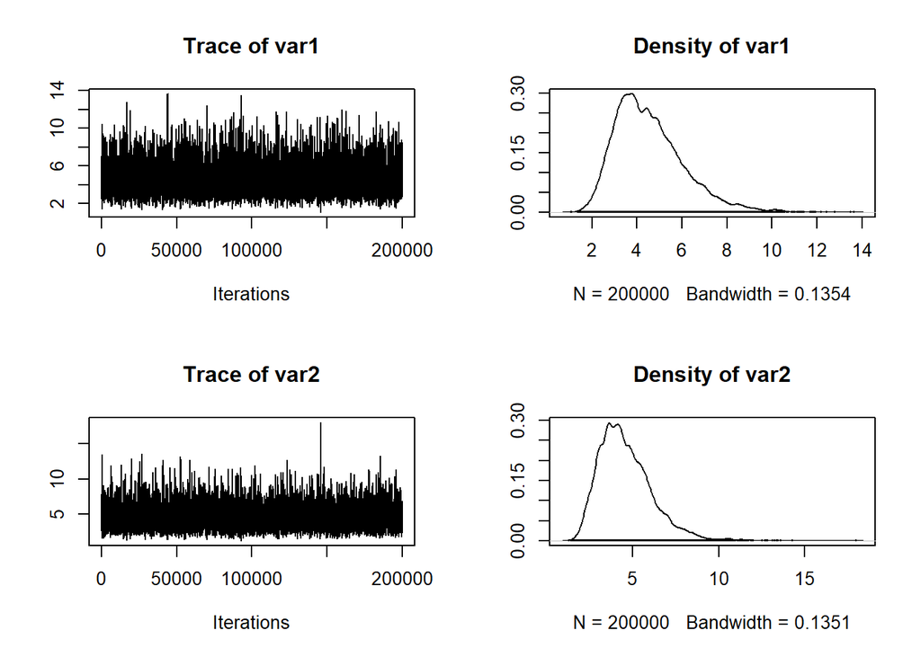

```r
plot(thetac1)
```

### Interpretasi

Salah satu cara melihat konvergen atau tidak bisa dilihat dari plotnya, jika garis densitynya mulus, dia bisa dibilang konvergen, jika masih bergerigi atau ada lonjakan, bisa ditambah iterasinya. Kemudian bisa juga dilihat dari tracenya, jika berbentuk seperti ulat gemuk, bisa dibilang konvergen.

### Uji Geweke

```r
geweke.diag(thetac1)
```

```
##
## Fraction in 1st window = 0.1
## Fraction in 2nd window = 0.5
##
##   var1   var2
##  1.122 -1.858
```

### Interpretasi Geweke

Jika kita menggunakan Uji Geweke, hasilnya jika dilihat dari Z-score (dengan tingkat signifikansi 5%), var1 dan var2 berada diantara -1.96 dan 1.96 artinya Gagal tolak H0, konvergen.

### Uji Raftery

```r
raftery.diag(thetac1)
```

```
##
## Quantile (q) = 0.025
## Accuracy (r) = +/- 0.005
## Probability (s) = 0.95
##
##  Burn-in  Total  Lower bound  Dependence
##  (M)      (N)    (Nmin)       factor (I)
##  106      114769 3746         30.6
##  100      108159 3746         28.9
```

### Uji Heidel

```r
heidel.diag(thetac1)
```

```
##
##      Stationarity start     p-value
##      test         iteration
## var1 passed       1         0.781
## var2 passed       1         0.681
##
##      Halfwidth Mean Halfwidth
##      test
## var1 passed    4.55 0.0437
## var2 passed    4.56 0.0435
```

### Interpretasi Uji Heidel

Untuk uji Heidel menghasilkan passed, yang berarti dapat dikatakan stasioner.

### Uji Gelman

Uji Gelman dibutuhkan dua chain, maka dibuituhkan 1 chain lagi

```r
library(coda)
set.seed(12)
thetac2 <- as.mcmc(MHfunc(3, 3, 200000, data))
```

```r
thetac <- list(thetac1, thetac2)
gelman.diag(thetac)
```

```
## Potential scale reduction factors:
##
##      Point est. Upper C.I.
## [1,]          1          1
## [2,]          1          1
##
## Multivariate psrf
##
## 1
```

### Interpretasi Uji Gelman

Untuk uji Gelman hasilnya bisa dikatakan konvergen karena nilai Upper C.Inya = 1.

## Contoh Metropolis Hasting (4)

Diketahui
$$\begin{align*}
X_i & \sim {\sf Normal}(\theta,\sigma^2), i = 1,\dots,n \\
\theta & \sim {\sf Normal} (\theta_0,\tau^2), \\
\sigma^2 & \sim {\sf IG} (a,b) \\
\end{align*}$$

Catatan: IG adalah Invers Gamma. Jika $\sigma^2$ berdistribusi Invers Gamma, berarti $1/\sigma^2$ berdistribusi gamma. Estimasi parameter $\theta$ dan $\sigma$.

Jawab: Likelihood:
$$\begin{align*}
p(x|\theta,\sigma^2) & = \prod_{i = 1}^{n} \frac{1}{\sqrt{2\pi\sigma^2}} exp( \frac{-(x_i-\theta)^2}{2\sigma^2}) \\
& = (2\pi \sigma^2)^{-n/2} exp(-1/{2\sigma^2}\sum_{i=1}^{n} (x_i-\theta)^2)
\end{align*}$$

Prior:
$$\begin{align*}
p(\theta,\sigma^2)=\frac{1}{\sqrt{2\pi\tau^2}}exp(\frac{-(\theta-\theta_0)^2}{2\tau^2}) \ b^2/{\Gamma(a)}(\sigma^2)^{-a-1}exp(-b/\sigma^2)
\end{align*}$$

Distribusi proposal Normal positif
$$\begin{align*}
\mu-6\sigma & > 0 \\
\mu & > 6\sigma \\
\sigma & > \mu/6 \\
\\
\theta_{t+1} \sim {\sf Normal}(\theta_t, \theta_{t/6}) \\
\alpha(x,y) & = min\{1,\frac{(2\pi\sigma_{new}^2)^{-n/2}\exp(-\frac{1}{2\sigma_{new}^2}\sum(X_i-\theta_{new}^2))\frac{1}{\sqrt{2\pi\tau^2}}exp(-\frac{(\theta_{new}-\theta_0)^2}{2\theta_{new}}) \ \frac{b^a}{\Gamma(a)}(\sigma_{new}^2)^{-a-1}exp(-b/\sigma_{new}^2)\frac{1}{\sqrt{2\pi(\theta_{new}/6)^2}}exp(-\frac{\theta_{old}-\theta_{new})^2}{2(\theta_{new}/6)})}{(2\pi\sigma_{old}^2)^{-n/2}\exp(-\frac{1}{2\sigma_{old}^2}\sum(X_i-\theta_{old}^2))\frac{1}{\sqrt{2\pi\tau^2}}exp(-\frac{(\theta_{old}-\theta_0)^2}{2\theta_{old}}) \ \frac{b^a}{\Gamma(a)}(\sigma_{old}^2)^{-a-1}exp(-b/\sigma_{old}^2)\frac{1}{\sqrt{2\pi(\theta_{old}/6)^2}}exp(-\frac{\theta_{new}-\theta_{old})^2}{2(\theta_{old}/6)})}\}
\end{align*}$$

### Membangkitkan data

```r
set.seed(221810445)
data <- rnorm(150, 7, 16)
```

### Metropolis Hasting

```r
MHfunc <- function(t, s, n, data){ #t=theta, s=sigma, n=banyak iterasi

  theta <- matrix(rep(0, 2*n), n, 2)

  # inisial
  theta[1, 1:2] <- c(t, s)

  library(invgamma)

  # hiperparameter
  for(i in 2:n){
    t.new <- rnorm(1, theta[i-1, 1], theta[i-1, 1]/6)
    s.new <- sqrt(rnorm(1, theta[i-1, 2]^2, theta[i-1, 2]^2/6))
    log.postnew <- sum(dnorm(data, t.new, s.new, log = TRUE)) + dnorm(t.new, 0, 10^3, log = TRUE) + dinvgamma(s.new^2, 10^(-3), 10^(-3), log = TRUE) + dnorm(theta[i-1, 1], t.new, t.new/6, log = TRUE) + dnorm(theta[i-1, 2]^2, s.new^2, s.new^2/6, log = TRUE)
    log.postold <- sum(dnorm(data, theta[i-1, 1], theta[i-1, 2], log = TRUE)) + dnorm(theta[i-1, 1], 0, 10^3, log = TRUE) + dinvgamma(theta[i-1, 2]^2, 10^(-3), 10^(-3), log = TRUE) + dnorm(t.new, theta[i-1, 1], theta[i-1, 1]/6, log = TRUE) + dnorm(s.new^2, theta[i-1, 2]^2, theta[i-1, 2]^2/6, log = TRUE)
    logprob <- log.postnew - log.postold
    aprob <- min(1, exp(logprob))
    u <- runif(1)
    if (u < aprob){
      theta[i,(1:2)] <- c(t.new, s.new)
    }else{
      theta[i,(1:2)] <- theta[i-1, (1:2)]
    }
  }

  theta
}
```

#### Mencoba menjalankan MH

```r
library(coda)
set.seed(221810445)
thetac1 <- as.mcmc(MHfunc(2, 10, 100000, data))
summary(thetac1)
```

```
##
## Iterations = 1:1e+05
## Thinning interval = 1
## Number of chains = 1
## Sample size per chain = 1e+05
##
## 1. Empirical mean and standard deviation for each variable,
##    plus standard error of the mean:
##
##        Mean     SD Naive SE Time-series SE
## [1,]  6.103 1.2763 0.004036       0.018307
## [2,] 15.513 0.9064 0.002866       0.007601
##
## 2. Quantiles for each variable:
##
##        2.5%    25%    50%    75%  97.5%
## var1  3.587  5.257  6.092  6.955  8.624
## var2 13.862 14.882 15.470 16.092 17.414
```

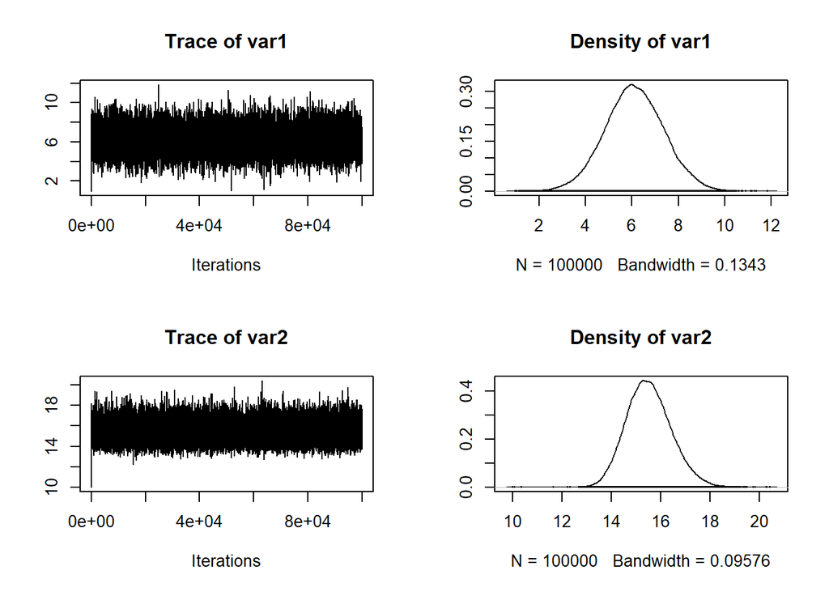

```r
plot(thetac1)
```

Jika dilihat dari tracenya sudah terlihat sepertiulat bulu gemuk yang bisa diasumsikan bahwa datanya konvergen.

Kemudian jika dilihat dari rata-rata estimasinya juga mendekati seperti aslinya, rata-rata estimasi yang dihasilkan sebesar 6.1 (theta) dan 15.5 (sigma) sedangkan aslinya adalah 7 dan 16. Jika diperinci, nilai theta 95% berada diantara 3.587 sampai 8.624. Sedangkan nilai sigma berada pada rentang 13.862 sampai 17.414.

```r
geweke.diag(thetac1)
```

```
##
## Fraction in 1st window = 0.1
## Fraction in 2nd window = 0.5
##
##    var1    var2
## -0.4786  1.0662
```

Jika kita menggunakan Uji Geweke, hasilnya jika dilihat dari Z-score (dengan tingkat signifikansi 5%) adalah Gagal tolak H0 yang artinya konvergen.

```r
raftery.diag(thetac1)
```

```
##
## Quantile (q) = 0.025
## Accuracy (r) = +/- 0.005
## Probability (s) = 0.95
##
##  Burn-in  Total Lower bound  Dependence
##  (M)      (N)   (Nmin)       factor (I)
##  70       72597 3746         19.40
##  15       15783 3746          4.21
```

Hasil dari uji Raftery: Total iterasi yang dibutuhkan adalah sebanyak 72 ribu dan 15 ribu, sedangkan iterasi yang kita gunakan sebanyak 100000. Ini berarti iterasi sudah bisa dikatakan cukup. Kemudian nilai I cukup besar yang berarti variabel dependen.

```r
heidel.diag(thetac1)
```

```
##
##      Stationarity start     p-value
##      test         iteration
## var1 passed       1         0.956
## var2 passed       1         0.556
##
##      Halfwidth Mean Halfwidth
##      test
## var1 passed     6.1 0.0359
## var2 passed    15.5 0.0149
```

Untuk uji Heidel menghasilkan passed, yang berarti dapat dikatakan stasioner.

```r
thetac2 <- as.mcmc(MHfunc(2.5, 11, 100000, data))

thetac <- list(thetac1, thetac2)

gelman.diag(thetac)
```

```
## Potential scale reduction factors:
##
##      Point est. Upper C.I.
## [1,]          1          1
## [2,]          1          1
##
## Multivariate psrf
##
## 1
```

Untuk uji Gelman hasilnya bisa dikatakan konvergen karena nilai Upper C.Inya = 1.

## Contoh Metropolis Hasting (5)

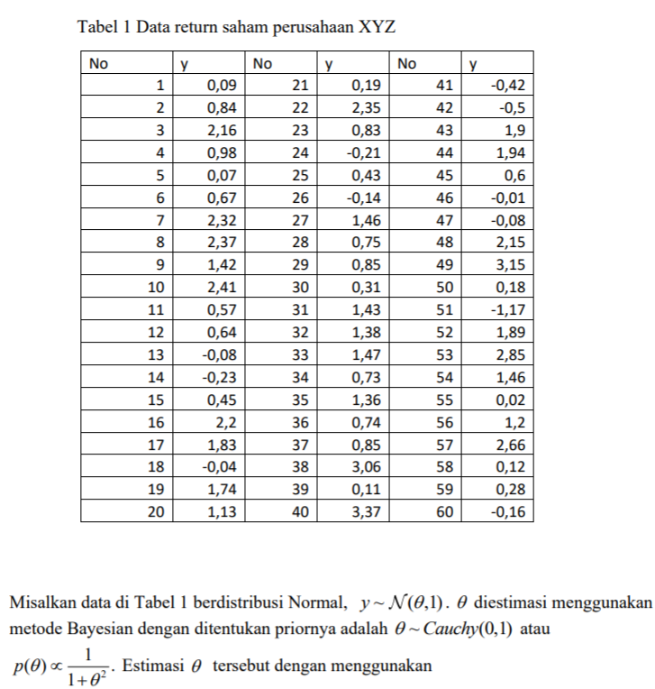

Jawab: Posterior:

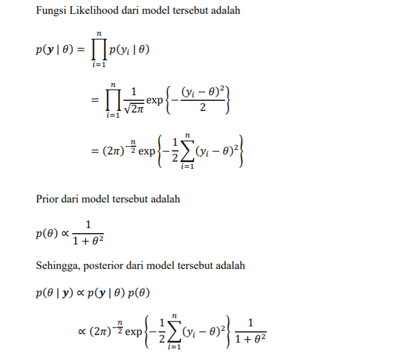

Maka densitas proposal $q(\theta_{t+1}|\theta_t)$ adalah

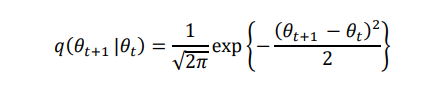

Sehingga peluang penerimaan $\alpha(\theta_{t+1},\theta_t)$ adalah

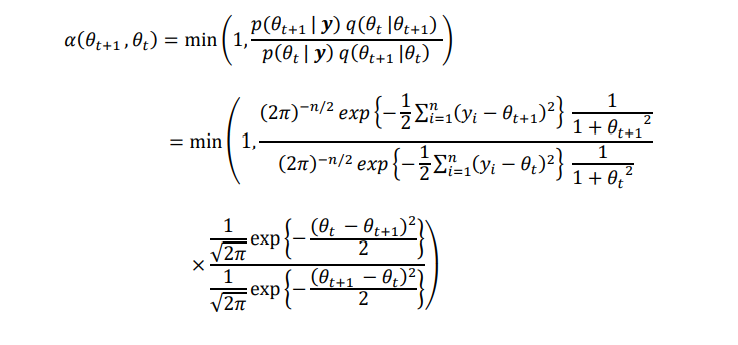

```r
sampleMH <- function(mu, n.sims, data){
 theta <- matrix(NA, nrow = n.sims, ncol = 1, dimnames = list(c(), c("theta")))
 # inisial
 theta[1, ] <- c(mu)
 for(i in 2:n.sims){
 t.new <- rnorm(1, theta[i-1, 1], 1)
 log.num <- sum(dnorm(data, t.new, 1, log = TRUE)) + dt(t.new, 1, log = TRUE) + dnorm(theta[i-1, 1], t.new, 1, log = TRUE)
 log.den <- sum(dnorm(data, theta[i-1, 1], 1, log = TRUE)) + dt(theta[i-1, 1], 1, log = TRUE) + dnorm(t.new, theta[i-1, 1], 1, log = TRUE)
 logprob <- log.num - log.den
 aprob <- min(1, exp(logprob))
 u <- runif(1)
 if (u < aprob){
  theta[i, ] <- c(t.new)
  } else {
    theta[i, ] <- theta[i-1, ]
  }
 }
 theta
}
```

### Menjalankan Code

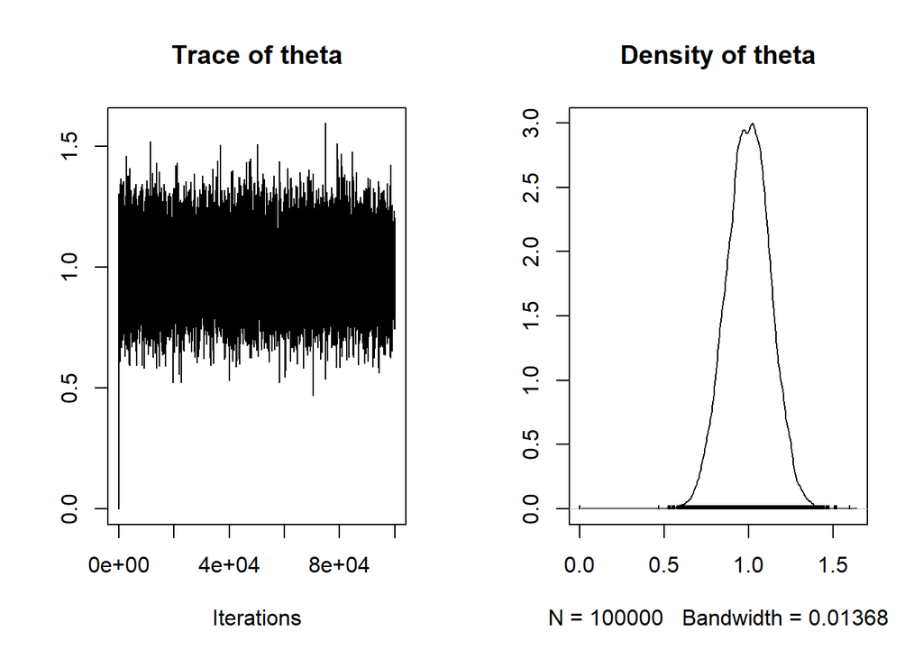

```r
data<-read.csv2("data/quiz.csv")
data<-data[,2]
thetamh1 <- as.mcmc(sampleMH(0, 100000, data))
plot(thetamh1)
```

Plot trace terlihat seperti ulat bulu gemuk dan plot dari desity sudah cukup mulus, sehingga dapat dikatakan konvergen.

### Uji Geweke

```r
geweke.diag(thetamh1)
```

```
##
## Fraction in 1st window = 0.1
## Fraction in 2nd window = 0.5
##
##    theta
## -0.04502
```

### Interpretasi Geweke

Jika kita menggunakan Uji Geweke, hasilnya jika dilihat dari Z-score (dengan tingkat signifikansi 5%), theta berada diantara -1.96 dan 1.96 artinya Gagal tolak H0, konvergen.

### Uji Raftery

```r
raftery.diag(thetamh1)
```

```
##
## Quantile (q) = 0.025
## Accuracy (r) = +/- 0.005
## Probability (s) = 0.95
##
##        Burn-in  Total Lower bound  Dependence
##        (M)      (N)   (Nmin)       factor (I)
##  theta 28       29920 3746         7.99
```

### Uji Heidel

```r
heidel.diag(thetamh1)
```

```
##
##       Stationarity start     p-value
##       test         iteration
## theta passed       1         0.644
##
##       Halfwidth Mean  Halfwidth
##       test
## theta passed    0.997 0.00238
```

### Interpretasi Uji Heidel

Untuk uji Heidel menghasilkan passed, yang berarti dapat dikatakan stasioner.